# Tecnologías digitales en colegios públicos peruanos (2021)

Práctica calificada 2

Guillermo Coronado Sialer

# Computadoras de escritorio para el uso pedagógico en colegios de educación primaria según su área

Tabla 1. Perú: porcentaje de computadoras de escritorio para uso pedagógico en colegios de educación primaria según área (2021)

| Cantidad de equipos | Área Urbana | Área Rural |
| --- | --- | --- |
| Ningún equipo | 32.7 | 58.4 |
| Menos de 20 equipos | 39.9 | 33.9 |
| De 20 a 59 equipos | 25.5 | 7.7 |
| De 60 a 100 equipos | 1.9 | 0.0 |
| Más de 100 equipos | 0.1 | 0.0 |

<sup>1</sup> Fuente: Enedu, INEI (2021). Elaboración propia

La **Tabla 1** nos permite comparar las diferencias en el número de computadoras de escritorio (PCs) entre los colegios de educación primaria de áreas urbanas y rurales. En ella, podemos observar que, en líneas generales, las escuelas primarias rurales cuentan con menos equipos, al punto que incluso más de la mitad de ellas (58.4%) no cuenta con ninguno, frente al 32.7% de escuelas primarias urbanas sin estos equipos. Asimismo, podemos ver también que, si bien el porcentaje de escuelas con menos de 20 equipos es relativamente similar en ambas zonas, tan solo un 7.7% de las escuelas primarias rurales cuentan con entre 20 y 59 de estos equipos, frente a un 25.5% de las escuelas primarias urbanas. Por último, encontramos que, si bien muy pocos colegios primarios en el área urbana poseen de 60 equipos a más, las escuelas primarias rurales están en desventaja, ya que ninguna de ellas tiene tantos equipos.

# Computadoras portátiles operativas en el aula de clase de colegios de educación primaria según su área

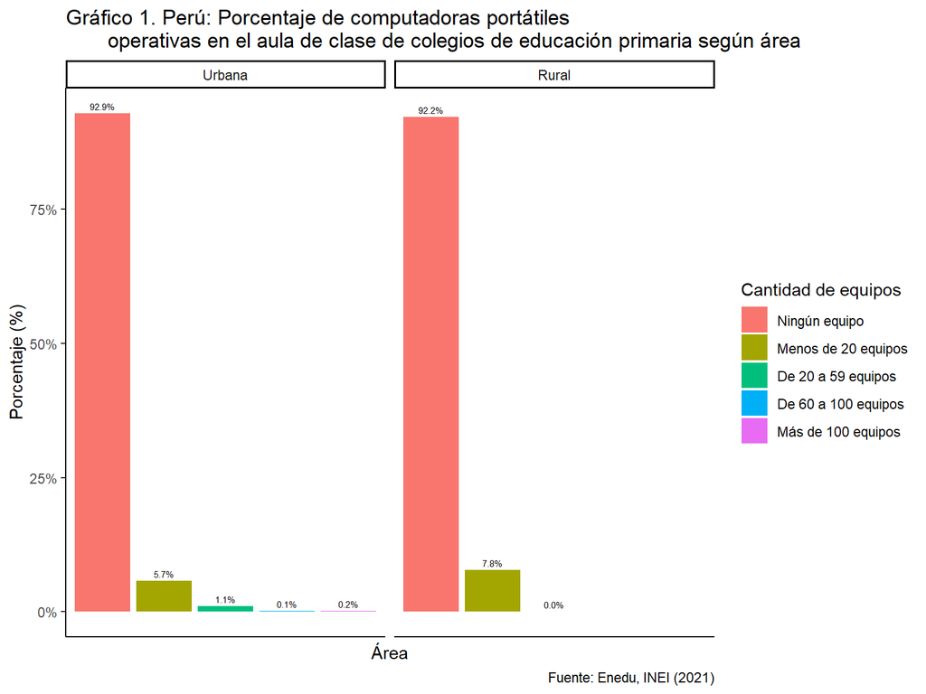

El **Gráfico 1** nos permite comparar las cantidades de computadoras portátiles (laptops) operativas que poseen las escuelas primarias en sus aulas de clase de acuerdo a su área (urbana o rural). Como podemos observar, en lo que respecta a la posesión de esta tecnología no hay grandes diferencias entre las áreas urbanas y rurales, ya que, en general, la mayoría de las escuelas primarias de ambas zonas no cuentan con ninguno de estos equipos (el 92.9% de las escuelas urbanas y el 92.2% de las escuelas rurales). Asimismo, las pocas escuelas primarias que cuentan con laptops en sus aulas, poseen en su mayoría menos de 20 de estos equipos (el 5.7% de las escuelas de áreas urbanas y el 7.8% de las escuelas de áreas rurales), y es tan solo un número minúsculo de escuelas urbanas las que poseen entre 20 y 59 equipos o incluso más de 100 equipos (1.1% y 0.2% de las escuelas primarias de áreas urbanas, respectivamente).

# Computadoras de escritorio para el uso pedagógico en colegios de educación secundaria según su área

Tabla 2. Perú: porcentaje de computadoras de escritorio para uso pedagógico en colegios de educación secundaria según área (2021)

| Cantidad de equipos | Área Urbana | Área Rural |
| --- | --- | --- |
| Ningún equipo | 24.9 | 40.5 |
| Menos de 20 equipos | 32.2 | 39.2 |
| De 20 a 59 equipos | 34.5 | 19.9 |
| De 60 a 100 equipos | 6.4 | 0.4 |
| Más de 100 equipos | 2.0 | 0.0 |

<sup>1</sup> Fuente: Enedu, INEI (2021). Elaboración propia

La **Tabla 2** compara la cantidad de computadoras de escritorio destinadas al uso pedagógico que poseen las escuelas secundarias del Perú según su área (urbana o rural). Al igual que en el caso de las escuelas primarias, vemos que las escuelas de áreas urbanas se encuentran mejor posicionadas en cuanto al acceso a esta tecnología. Así, vemos que, mientras el 40.5% de las escuelas rurales no cuenta con ninguno de estos equipos, esto solo sucede en el 24.9% de escuelas urbanas. Nuevamente, vemos que la brecha entre ambas zonas se acorta entre las escuelas que tienen menos de 20 computadoras (el 32.2% de escuelas secundarias en el área urbana y el 39.2% en el área rural); sin embargo, mientras el 34.5% de escuelas secundarias urbanas poseen entre 20 y 59 equipos, tan solo el 19.9% de escuelas rurales posee esta cantidad. Por último, podemos observar que, si bien no son muchas las escuelas en general que poseen de 60 computadoras a más, el porcentaje de escuelas de áreas urbanas que tiene a partir de este número de equipos (6.4%) sigue siendo mayor al de escuelas de áreas rurales que también poseen esta cantidad (tan solo 0.4%.Lo mismo sucede con las escuelas que poseen más de 100 equipos, en donde vemos que, mientras no hay ninguna escuela rural con tal cantidad de equipos, un 2% de las escuelas secundarias de áreas urbanas cuentan con dicho número de equipos.

# Computadoras portátiles operativas en el aula de clase de colegios de educación secundaria según su área

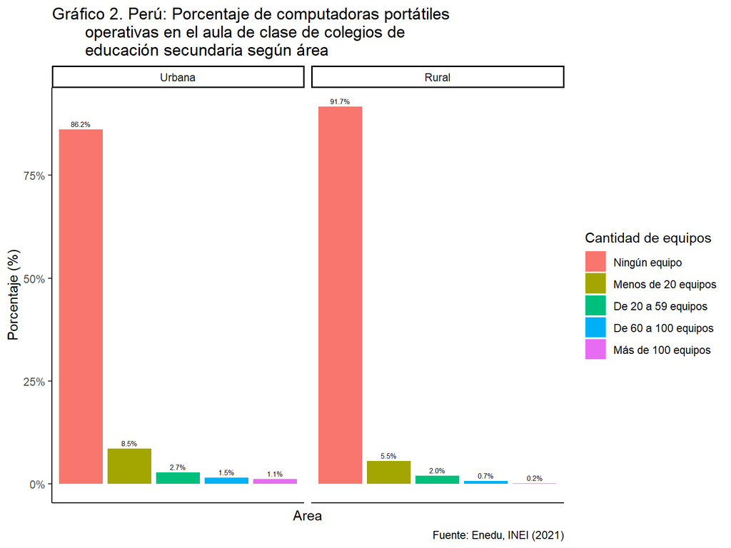

El **Gráfico 2** compara la cantidad de laptops operativas en el aula de clase que poseen los colegios de educación secundaria en el Perú, de acuerdo al área (urbana o rural) en donde se ubican. Al igual que para el caso de las escuelas primarias, podemos ver que, tanto en zonas urbanas como rurales, la gran mayoría de colegios no cuentan con ninguna laptop operativa en el aula de clase, aunque este porcentaje es un poco mayor en zonas rurales (91.7% frente al 86.2% de escuelas secundarias en zonas urbanas). Asimismo, el gráfico nos muestra que, para ambas zonas, el porcentaje de escuelas secundarias que poseen estos equipos es pequeño, sobre todo en el caso de los que poseen de 60 a 99 equipos o de 100 equipos a más. No obstante, si bien la distribución es similar en ambas zonas, el porcentaje de escuelas secundarias urbanas que poseen estos equipos sigue siendo ligeramente mayor. Así, por ejemplo, mientras el 8.5% de las escuelas secundarias urbanas cuenta con estos equipos, este es el caso de solo 5.5% de las escuelas secundarias rurales, y, mientras el 1.5% de escuelas urbanas cuenta con entre 60 y 100 laptops, este es el caso de tan solo el 0.7% de las escuelas rurales.

# Número total de tecnologías digitales para uso pedagógico de escuelas que cuentan con primaria y secundaria según su área

Tabla 3. Perú: Número total de tecnologías digitales para uso pedagógico en colegios que cuentan con educación primaria y secundaria según área (2021)

| Cantidad de equipos | Área Urbana | Área Rural |
| --- | --- | --- |
| Ningún equipo | 2.0 | 3.5 |
| Menos de 50 equipos | 18.8 | 12.1 |
| De 50 a 99 equipos | 17.8 | 22.5 |
| De 100 a 150 equipos | 15.9 | 16.0 |
| Más de 150 equipos | 45.4 | 45.9 |

<sup>1</sup> Fuente: Enedu, INEI (2021). Elaboración propia